# Beach Debris Exploration

### CISC367 Final Project - Maria van Venrooy

## Societal Problem: Overconsumption and Resulting Plastic Pollution

The introduction of synthetic plastic was groundbreaking for human manufacturing. Instead of being dependent on nature for building materials (wood, stone, metal, etc), humans could now create their own. According to sciencehistory.org, "The possibilities of plastics gave some observers an almost utopian vision of a future with abundant material wealth thanks to an inexpensive, safe, sanitary substance that could be shaped by humans to their every whim" (1).

Plastic production hase been steadily increasing for decades. In 1950, 1.5 million metric tons of plastic were produced. In 2019, the amount of plastic produced increased more than 200-fold to 368 million metric tons (2). One of plastic's most valuable features, its durability, quickly made plastic a nuissance. In the 1960s, plastic debris was first observed in the oceans (1).

Today, there are more than 5.25 trillion pieces of plastic in the ocean - about 46,000 pieces per square mile (3). An estimated 8 million pieces of plastic make their way into the oceans every single day (3). And this plastic is not going away any time soon - the EPA reports that all the plastic that has ever been made still exists today (7).

## Problem Justification: Negative Consequences of Plastic Pollution

#### Microplastics - extremely small pieces of plastic

Plastic pollution affects nearly all life on the planet, from microscopic zooplankton(4) to hundred-ton blue whales (5). When zooplankton consume microplastics, it never decomposes, and so remains in the zooplankton's system for its entire lifespan. When the zooplankton is consumed by other marine creatures, the plastic starts to accumulate in those creatures, and so on as the plastic moves up the food chain (4). Humans end up consuming plastic when they eat salmon, tuna, and other fish with plastic in their muscle tissue (6). Frighteningly, researchers don't know very much about the effects of ingesting plastic on fish on humans (6).

#### Larger Plastics

Microplastics aren't the only kind of plastic that are wreaking havoc on the environment. Thousands of animals, including seabirds, sea turtles, and seals are killed each year from ingesting or getting caught in plastic litter, and many more are seriously injured (7).

## Research Questions

#### Does the type of beach (sandy vs. rocky vs. pebbles) affect the type and amount of litter and debris found?

The type of beach depends of the energy of the waves that hit the beach, so this could have a significant impact on the kind of debris found (8). Answering this question could be useful, as it could lead to more effective cleanups. For example, if rocky beaches tend to have more large debris, like tires and boat parts, different equipment may be more effective than what you would use to collect and dispose of small pieces of debris like plastic bottles and grocery bags.

#### Have the COVID-19 Pandemic and associated lockdowns affected the type and/or amount of litter and debris found on beaches?

The COVid-19 pandemic has greatly influenced consumer habits (9). If there is a correlation between the pandemic and marine debris, we may be able to draw conclusions about how and how fast human activity affects marine debris.

## Datasets

The data set used is from [*Marine Litter Watch: Litter on the beach*](https://www.kaggle.com/maartenvandevelde/marine-litter-watch-19502021). This dataset is broken into 2 csvs: "MLW_Data.csv" and "MLW_Meta.csv". The Data csv file contains statistics from beach cleanups and monitoring visits on different dates and in different locations. Each cleanup or monitoring visit is a row, and contains the date of the visit, the beach type, the location, and the quantities of different types of items found. Columns that begin with a "G" followed by a number each represent a specific type of item, for example shopping bags, drink bottles, cardboard boxes, etc. The Meta csv tells us what each of the G-number codes represent.

## Data Exploration

```python
#Imports, and getting a look at the Data csv

import pandas as pd
import numpy as np
import matplotlib.pyplot as plt
pd.options.mode.chained_assignment = None  # suppress some warnings


df = pd.read_csv("MLW_Data.csv")

df
```

|  | CommunityName | BeachName | BeachCountrycode | BeachRegionalSea | BeachLength_m | BeachLocation | BeachType | EventDate | EventType | NatRef | ... | G202 | G203 | G204 | G205 | G206 | G207 | G208 | G210 | G211 | G213 |
| --- | --- | --- | --- | --- | --- | --- | --- | --- | --- | --- | --- | --- | --- | --- | --- | --- | --- | --- | --- | --- | --- |
| 0 | gBqsPxAZ | krapetz | BG | Black Sea | 5850 | Rural | Sandy | 20160310 | Cleanup | NaN | ... | 2.0 | 4.0 | NaN | 3.0 | NaN | NaN | 3.0 | NaN | 1.0 | NaN |
| 1 | gBqsPxAZ | krapetz | BG | Black Sea | 5850 | Rural | Sandy | 20150902 | Cleanup | NaN | ... | 1.0 | NaN | 2.0 | NaN | NaN | NaN | 7.0 | 3.0 | NaN | NaN |
| 2 | gBqsPxAZ | krapetz | BG | Black Sea | 5850 | Rural | Sandy | 20151203 | Cleanup | NaN | ... | NaN | NaN | 5.0 | NaN | NaN | NaN | 2.0 | NaN | 2.0 | 1.0 |
| 3 | gBqsPxAZ | krapetz | BG | Black Sea | 5850 | Rural | Sandy | 20151008 | Cleanup | NaN | ... | 5.0 | NaN | 2.0 | NaN | NaN | NaN | 5.0 | 26.0 | NaN | NaN |
| 4 | Legambiente Onlus | San Mauro Cilento (SA) | IT | Unknown | 100 | NaN | NaN | 20180428 | Monitoring | NaN | ... | NaN | NaN | NaN | NaN | NaN | NaN | 3.0 | NaN | 2.0 | NaN |
| ... | ... | ... | ... | ... | ... | ... | ... | ... | ... | ... | ... | ... | ... | ... | ... | ... | ... | ... | ... | ... | ... |
| 3408 | Legambiente Onlus | Spiaggia di Marina di Montemarciano, Ancona (AN) | IT | Mediterranean Sea | 100 | NaN | NaN | 20160505 | Monitoring | NaN | ... | 1.0 | NaN | NaN | NaN | NaN | NaN | NaN | 1.0 | NaN | NaN |
| 3409 | Surfrider Foundation Europe | La Lagune, 33260 La Teste de Buch, FRANCE | FR | North-east Atlantic Ocean | 548 | NaN | NaN | 20180602 | Cleanup | NaN | ... | NaN | NaN | NaN | NaN | NaN | NaN | 1.0 | NaN | NaN | NaN |
| 3410 | Surfers Against Sewage | Bournemouth beach | UK | North-east Atlantic Ocean | 2302 | Urban | Sandy | 20150328 | Cleanup | NaN | ... | NaN | NaN | NaN | NaN | NaN | NaN | 8.0 | NaN | NaN | NaN |
| 3411 | ocean-R-evolution.com | cleanuptravels.com | CH | NaN | 22 | Rural | Sandy | 20170315 | Cleanup | NaN | ... | NaN | NaN | NaN | NaN | NaN | NaN | 1.0 | NaN | NaN | NaN |
| 3412 | Marnoba | Las Salinas de Cabo de Gata, Almer�a | ES | Mediterranean Sea | 100 | Near river mouth | Sandy | 20130923 | Cleanup | NaN | ... | NaN | NaN | NaN | NaN | NaN | NaN | NaN | NaN | NaN | NaN |

3413 rows × 176 columns

## General Dataset Info

```python
# Let's look at the Meta csv

metadf = pd.read_csv("MLW_Meta.csv")
metadf.head()
```

|  | generalcode | category | generalname |
| --- | --- | --- | --- |
| 0 | G1 | Plastic | 4/6-pack yokes, six-pack rings |
| 1 | G3 | Plastic | Shopping Bags incl. pieces |
| 2 | G4 | Plastic | Small plastic bags, e.g. freezer bags incl. pi... |
| 3 | G5 | Plastic | Plastic bags collective role; what remains fro... |
| 4 | G7 | Plastic | Drink bottles <=0.5l |

Here, some value counts to get an idea of what the data looks like

```python
print(df["BeachType"].value_counts())
```

```
Sandy            732
Pebbels          398
Other (mixed)    384
Rocky            174
Name: BeachType, dtype: int64
```

The most common beach type visited was "Sandy", followed by "Pebbels", "Other (mixed)", and then "Rocky". The counts are all in the hundreds, so we should have enough data to compare the categories against each other

```python
print(df["EventType"].value_counts())
```

```
Cleanup       2623
Monitoring     790
Name: EventType, dtype: int64
```

The vast majority of the events were Cleanup events, where participants removed the found items.

```
array([[<AxesSubplot:title={'center':'EventDate'}>]], dtype=object)
```

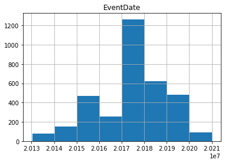

```python
df.hist(column = "EventDate", bins =8)
```

Finding: dates range from 2013 to 2021, and 2017 is the year with the most cleanups

```python
metadf
```

|  | generalcode | category | generalname |
| --- | --- | --- | --- |
| 0 | G1 | Plastic | 4/6-pack yokes, six-pack rings |
| 1 | G3 | Plastic | Shopping Bags incl. pieces |
| 2 | G4 | Plastic | Small plastic bags, e.g. freezer bags incl. pi... |
| 3 | G5 | Plastic | Plastic bags collective role; what remains fro... |
| 4 | G7 | Plastic | Drink bottles <=0.5l |
| ... | ... | ... | ... |
| 159 | G210 | Glass/ceramics | Other glass items |
| 160 | G211 | unidentified | Other medical items (swabs, bandaging, adhesiv... |
| 161 | G213 | Chemicals | Paraffin/Wax |
| 162 | G301 | Cloth/textile | Disposable mask |
| 163 | G302 | Cloth/textile | Disposable glove |

164 rows × 3 columns

Disposable mask and disposable glove are G301 and G302, respectively. I really wanted to see how the counts of these items changed over time, but unfortunately they are not included in the data csv.

```python
metadf["category"].value_counts()
```

```
Plastic                  89
Metal                    21
Processed/worked wood    11
Cloth/textile            11
Paper/Cardboard          10
Glass/ceramics           10
Rubber                   10
Chemicals                 1
unidentified              1
Name: category, dtype: int64
```

There are 89 different types of plastic categorized in the Meta csv, 21 different types of metal, and so on.

## Separating out the Plastic

Let's just look at the metadata for items in the "Plastic" category

```python
plasticmetadf = metadf[metadf["category"] == "Plastic"]

plasticmetadf.head()
```

|  | generalcode | category | generalname |
| --- | --- | --- | --- |
| 0 | G1 | Plastic | 4/6-pack yokes, six-pack rings |
| 1 | G3 | Plastic | Shopping Bags incl. pieces |
| 2 | G4 | Plastic | Small plastic bags, e.g. freezer bags incl. pi... |
| 3 | G5 | Plastic | Plastic bags collective role; what remains fro... |
| 4 | G7 | Plastic | Drink bottles <=0.5l |

Now, let's get the codes of all the plastic items so we can slice the Data csv and get only the plastic item counts

```python
PLASTIC_CODES = plasticmetadf["generalcode"]
PLASTIC_CODES
```

```
0       G1
1       G3
2       G4
3       G5
4       G7
      ...
84     G99
85    G100
86    G101
87    G102
88    G124
Name: generalcode, Length: 89, dtype: object
```

```python
#Now make a dataframe that includes the date, beach type,
# country, and all of the plastic columns

#slice the dates col
dates = df['EventDate']

#slice the beach types col
beachtypes = df["BeachType"]

#slice location col
countries = df["BeachCountrycode"]

#slice all the plastic cols
plastics_df = df[PLASTIC_CODES]

#add event date, beach type, and country into plastics_df
plastics_df['EventDate'] = dates
plastics_df["BeachType"] = beachtypes
plastics_df["Country"] = countries

#sum across plastic columns to get total plastic
totalPlast = plastics_df[PLASTIC_CODES].sum(axis=1);

#add the total column
plastics_df["Total Plastic"] = totalPlast

#format the date column
plastics_df['EventDate'] = pd.to_datetime(df['EventDate'], format='%Y%m%d')


plastics_df.head()
```

|  | G1 | G3 | G4 | G5 | G7 | G8 | G9 | G10 | G11 | G12 | ... | G98 | G99 | G100 | G101 | G102 | G124 | EventDate | BeachType | Country | Total Plastic |
| --- | --- | --- | --- | --- | --- | --- | --- | --- | --- | --- | --- | --- | --- | --- | --- | --- | --- | --- | --- | --- | --- |
| 0 | NaN | NaN | 1.0 | NaN | 8.0 | 31.0 | 2.0 | 4.0 | NaN | 1.0 | ... | NaN | 1.0 | NaN | NaN | NaN | NaN | 2016-03-10 | Sandy | BG | 214.0 |
| 1 | NaN | 12.0 | 1.0 | NaN | 10.0 | 9.0 | NaN | 2.0 | 3.0 | NaN | ... | NaN | NaN | NaN | NaN | 1.0 | 21.0 | 2015-09-02 | Sandy | BG | 954.0 |
| 2 | NaN | 27.0 | 7.0 | NaN | 3.0 | 8.0 | 1.0 | 9.0 | NaN | 1.0 | ... | NaN | NaN | 2.0 | NaN | NaN | NaN | 2015-12-03 | Sandy | BG | 210.0 |
| 3 | NaN | 15.0 | 60.0 | NaN | 18.0 | 46.0 | NaN | 9.0 | 10.0 | 5.0 | ... | 1.0 | 2.0 | NaN | NaN | 5.0 | 10.0 | 2015-10-08 | Sandy | BG | 1022.0 |
| 4 | NaN | 5.0 | 6.0 | NaN | 13.0 | 19.0 | 13.0 | 6.0 | 4.0 | 2.0 | ... | NaN | NaN | 2.0 | NaN | 1.0 | NaN | 2018-04-28 | NaN | IT | 506.0 |

5 rows × 93 columns

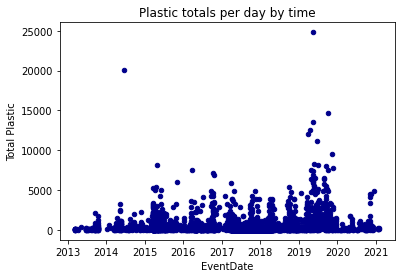

```python
ax1 = plastics_df.plot.scatter(y='Total Plastic',
                      x='EventDate',
                      c='DarkBlue',
                    title = "Plastic totals per day by time")
```

```python
#plastics_df_day_sum = plastics_df

plastics_df_day_sum = plastics_df.groupby('EventDate').mean().reset_index()

plastics_df_day_sum.head()
```

|  | EventDate | G1 | G3 | G4 | G5 | G7 | G8 | G9 | G10 | G11 | ... | G95 | G96 | G97 | G98 | G99 | G100 | G101 | G102 | G124 | Total Plastic |
| --- | --- | --- | --- | --- | --- | --- | --- | --- | --- | --- | --- | --- | --- | --- | --- | --- | --- | --- | --- | --- | --- |
| 0 | 2013-03-12 | NaN | 3.0 | NaN | NaN | 5.0 | NaN | 1.0 | NaN | NaN | ... | NaN | 0.000000 | NaN | NaN | NaN | NaN | NaN | NaN | 0.0 | 57.0 |
| 1 | 2013-03-13 | NaN | 2.0 | NaN | NaN | 3.0 | NaN | NaN | NaN | NaN | ... | 6.0 | 0.333333 | NaN | NaN | NaN | NaN | NaN | NaN | 0.0 | 31.0 |
| 2 | 2013-03-14 | NaN | 10.5 | NaN | NaN | 4.5 | NaN | NaN | 2.0 | NaN | ... | 14.0 | 4.500000 | NaN | NaN | NaN | 1.0 | NaN | NaN | 0.0 | 65.0 |
| 3 | 2013-03-15 | NaN | 5.0 | NaN | NaN | 14.0 | NaN | NaN | 3.0 | NaN | ... | NaN | 0.000000 | NaN | NaN | NaN | NaN | NaN | NaN | 0.0 | 76.5 |
| 4 | 2013-03-16 | NaN | 5.5 | NaN | NaN | 10.0 | NaN | 3.0 | 3.0 | NaN | ... | 2.0 | 0.500000 | NaN | NaN | NaN | NaN | NaN | NaN | 0.0 | 76.5 |

5 rows × 91 columns

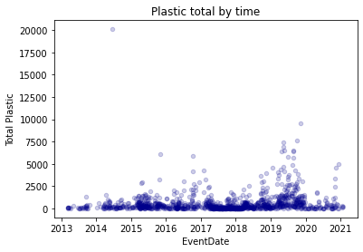

```python
ax1 = plastics_df_day_sum.plot.scatter(y='Total Plastic',
                      x='EventDate',
                    alpha = .2,
                      c='DarkBlue',
                           title = "Plastic total by time")
```

This did not work T.T

## Beach Type & Debris Size

In the Meta csv, some categories include the size of objects found. For example, G14 is "Plastic Engine oil bottles & containers <50 cm", and G15 is "Plastic Engine oil bottles & containers > 50 cm". I will use all of the columns that include the "greater than 50 cm" and "less than 50 cm" to compare the amount or large items against the amount of small items found at each beach type.

```python
#Manually go through Meta csv to get item codes that specify
#size greater than or less than 50 cm
```

```python
print(df["BeachType"].value_counts())
```

```
Sandy            732
Pebbels          398
Other (mixed)    384
Rocky            174
Name: BeachType, dtype: int64
```

```python
UNDER_50_CM_CODES = ['G14', 'G53', 'G76', 'G79', 'G82', 'G171', 'G198']

OVER_50_CM_CODES =  ['G15', 'G54', 'G77', 'G80', 'G83', 'G172', 'G199']

#G14/15: Engine oil bottles & containers
#G53/54: Nets and pieces of net
#G76/77: Plastic/polystyrene pieces
#G79/80: Plastic pieces
#G82/83: Polystyrene pieces
#G171/172: Other wood
#G198/199: Other metal pieces

size_df = df
#print(size_df[UNDER_50_CM_CODES])
```

```python
totalSmall = size_df[UNDER_50_CM_CODES].sum(axis=1);

size_df['Total Small'] = totalSmall

totalBig = size_df[OVER_50_CM_CODES].sum(axis=1);

size_df['Total Big'] = totalBig

size_df.head()
```

|  | CommunityName | BeachName | BeachCountrycode | BeachRegionalSea | BeachLength_m | BeachLocation | BeachType | EventDate | EventType | NatRef | ... | G204 | G205 | G206 | G207 | G208 | G210 | G211 | G213 | Total Small | Total Big |
| --- | --- | --- | --- | --- | --- | --- | --- | --- | --- | --- | --- | --- | --- | --- | --- | --- | --- | --- | --- | --- | --- |
| 0 | gBqsPxAZ | krapetz | BG | Black Sea | 5850 | Rural | Sandy | 20160310 | Cleanup | NaN | ... | NaN | 3.0 | NaN | NaN | 3.0 | NaN | 1.0 | NaN | 15.0 | 18.0 |
| 1 | gBqsPxAZ | krapetz | BG | Black Sea | 5850 | Rural | Sandy | 20150902 | Cleanup | NaN | ... | 2.0 | NaN | NaN | NaN | 7.0 | 3.0 | NaN | NaN | 226.0 | 10.0 |
| 2 | gBqsPxAZ | krapetz | BG | Black Sea | 5850 | Rural | Sandy | 20151203 | Cleanup | NaN | ... | 5.0 | NaN | NaN | NaN | 2.0 | NaN | 2.0 | 1.0 | 35.0 | 9.0 |
| 3 | gBqsPxAZ | krapetz | BG | Black Sea | 5850 | Rural | Sandy | 20151008 | Cleanup | NaN | ... | 2.0 | NaN | NaN | NaN | 5.0 | 26.0 | NaN | NaN | 68.0 | 7.0 |
| 4 | Legambiente Onlus | San Mauro Cilento (SA) | IT | Unknown | 100 | NaN | NaN | 20180428 | Monitoring | NaN | ... | NaN | NaN | NaN | NaN | 3.0 | NaN | 2.0 | NaN | 140.0 | 9.0 |

5 rows × 178 columns

Important note: this data is only based on items which fall into categories which specifically state size. For instance, items in the "Traffic cones" column are probably greater than 50 cm, and items in the "Paint brushed" column are probably less that 50 cm, but I only included columns that explicity state the size.

## MESSY NOTE:

I did the above work before getting Dr. Bart's guidance to do a distribution of individual beach's %large items, but I will leave it here bc messy

```python
#size_df_by_beach_type["% Items > 50 cm"] = 100 * size_df_by_beach_type['Total Big']/(size_df_by_beach_type['Total Big'] + size_df_by_beach_type['Total Small'])



size_df["% Big"] = 100 * size_df['Total Big'] / (size_df['Total Big'] + size_df['Total Small'])
size_df.head()
```

|  | CommunityName | BeachName | BeachCountrycode | BeachRegionalSea | BeachLength_m | BeachLocation | BeachType | EventDate | EventType | NatRef | ... | G205 | G206 | G207 | G208 | G210 | G211 | G213 | Total Small | Total Big | % Big |
| --- | --- | --- | --- | --- | --- | --- | --- | --- | --- | --- | --- | --- | --- | --- | --- | --- | --- | --- | --- | --- | --- |
| 0 | gBqsPxAZ | krapetz | BG | Black Sea | 5850 | Rural | Sandy | 20160310 | Cleanup | NaN | ... | 3.0 | NaN | NaN | 3.0 | NaN | 1.0 | NaN | 15.0 | 18.0 | 54.545455 |
| 1 | gBqsPxAZ | krapetz | BG | Black Sea | 5850 | Rural | Sandy | 20150902 | Cleanup | NaN | ... | NaN | NaN | NaN | 7.0 | 3.0 | NaN | NaN | 226.0 | 10.0 | 4.237288 |
| 2 | gBqsPxAZ | krapetz | BG | Black Sea | 5850 | Rural | Sandy | 20151203 | Cleanup | NaN | ... | NaN | NaN | NaN | 2.0 | NaN | 2.0 | 1.0 | 35.0 | 9.0 | 20.454545 |
| 3 | gBqsPxAZ | krapetz | BG | Black Sea | 5850 | Rural | Sandy | 20151008 | Cleanup | NaN | ... | NaN | NaN | NaN | 5.0 | 26.0 | NaN | NaN | 68.0 | 7.0 | 9.333333 |
| 4 | Legambiente Onlus | San Mauro Cilento (SA) | IT | Unknown | 100 | NaN | NaN | 20180428 | Monitoring | NaN | ... | NaN | NaN | NaN | 3.0 | NaN | 2.0 | NaN | 140.0 | 9.0 | 6.040268 |

5 rows × 179 columns

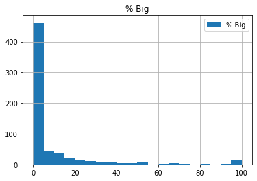

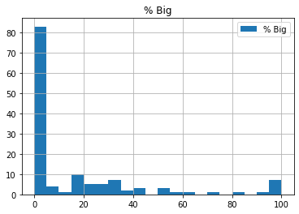

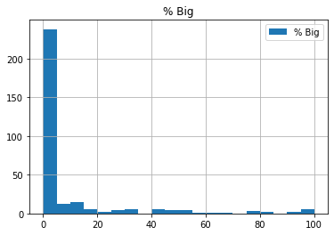

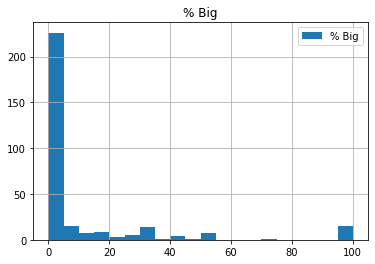

```python
types = ["Sandy", "Rocky", "Pebbels", "Other (mixed)"]

perc_big_dist_by_beach_type = {}

for i in types:
    perc_big_dist_by_beach_type[i] = size_df[size_df['BeachType'] == i]

for i in types:
    thisdf = perc_big_dist_by_beach_type[i]
    thisdf.hist(column = '% Big', bins=20, legend=True)

#rocky_perc = perc_big_dist_by_beach_type["Rocky"]

#rocky_perc.hist(column = "% Big", bins =10)
```

### ^Above: % Big Distributions for Sandy, Rocky, Pebbels, and Other (mixed)

### Result:

The distributions of percentages of big items retrieved at each beach type do not follow a normal distribution; they are all right skewed. Let's compare their distributions to eachother

```python
rockydist = perc_big_dist_by_beach_type['Rocky']['% Big']
sandydist = perc_big_dist_by_beach_type['Sandy']['% Big']

pebbeldist = perc_big_dist_by_beach_type['Pebbels']['% Big']
otherdist = perc_big_dist_by_beach_type['Other (mixed)']['% Big']
```

```python
from scipy import stats
```

```python
stats.kruskal(rockydist, otherdist, sandydist, pebbeldist, nan_policy='omit')
```

```
KruskalResult(statistic=13.740136763219578, pvalue=0.003281082744832735)
```

```python
stats.kruskal(sandydist, rockydist, nan_policy='omit')
```

```
KruskalResult(statistic=0.9978403812110318, pvalue=0.3178336372661171)
```

```python
stats.kruskal(sandydist, pebbeldist, nan_policy='omit')
```

```
KruskalResult(statistic=10.643455285304732, pvalue=0.0011046110433826904)
```

```python
stats.kruskal(sandydist, otherdist, nan_policy='omit')
```

```
KruskalResult(statistic=3.5710145582447477, pvalue=0.058796378012575076)
```

```python
stats.kruskal(rockydist, pebbeldist, nan_policy='omit')
```

```
KruskalResult(statistic=6.722389937485682, pvalue=0.009520995833156066)
```

```python
stats.kruskal(rockydist, otherdist, nan_policy='omit')
```

```
KruskalResult(statistic=3.0351710278209283, pvalue=0.08147796280643631)
```

```python
stats.kruskal(pebbeldist, otherdist, nan_policy='omit')
```

```
KruskalResult(statistic=1.119405627436315, pvalue=0.2900464737196865)
```

#### Finding:

The distribution of large item percentages at Pebbel beaches is significantly different from the distributions of both rocky and sandy beaches

## Beach Type and Debris Type

```python
#Get category codes for each type of material so we can get sums based on beach type

material_codes = {}
keys = {'Plastic', 'Rubber', 'Cloth/textile', 'Paper/Cardboard', 'Processed/worked wood', 'Metal', 'Glass/ceramics'}

for i in keys:
        material_codes[i] = metadf[metadf["category"] == i]['generalcode']

#G301 and G302 are in the Meta csv but are not included in the data, so we need to manually
#update the Cloth/textile codes to exclude those value

material_codes['Cloth/textile'] = [ 'G137',
 'G138',
 'G139',
 'G140',
 'G141',
 'G142',
 'G143',
 'G144',
 'G145']

#Now we have a dictionary where the keys are the category types (Plastic, rubber, etc),
#and their values are the column codes in that category


material_df = df

material_sums = {}

for j in keys:
        material_sums[j] = material_df[material_codes[j]].sum(axis=1)

for k in keys:
        material_df["Sum of " + k] = material_sums[k]
#G301 and G302 are in the Meta csv but are not included in the data, so we need to manually
#remove them from list of cloth/textile codes

#material_codes["Cloth/textile"]

material_df.head()
```

|  | CommunityName | BeachName | BeachCountrycode | BeachRegionalSea | BeachLength_m | BeachLocation | BeachType | EventDate | EventType | NatRef | ... | Total Small | Total Big | % Big | Sum of Processed/worked wood | Sum of Cloth/textile | Sum of Paper/Cardboard | Sum of Glass/ceramics | Sum of Plastic | Sum of Rubber | Sum of Metal |
| --- | --- | --- | --- | --- | --- | --- | --- | --- | --- | --- | --- | --- | --- | --- | --- | --- | --- | --- | --- | --- | --- |
| 0 | gBqsPxAZ | krapetz | BG | Black Sea | 5850 | Rural | Sandy | 20160310 | Cleanup | NaN | ... | 15.0 | 18.0 | 54.545455 | 3.0 | 2.0 | 6.0 | 13.0 | 214.0 | 2.0 | 9.0 |
| 1 | gBqsPxAZ | krapetz | BG | Black Sea | 5850 | Rural | Sandy | 20150902 | Cleanup | NaN | ... | 226.0 | 10.0 | 4.237288 | 10.0 | 24.0 | 43.0 | 17.0 | 954.0 | 3.0 | 15.0 |
| 2 | gBqsPxAZ | krapetz | BG | Black Sea | 5850 | Rural | Sandy | 20151203 | Cleanup | NaN | ... | 35.0 | 9.0 | 20.454545 | 5.0 | 3.0 | 19.0 | 11.0 | 210.0 | 6.0 | 8.0 |
| 3 | gBqsPxAZ | krapetz | BG | Black Sea | 5850 | Rural | Sandy | 20151008 | Cleanup | NaN | ... | 68.0 | 7.0 | 9.333333 | 0.0 | 16.0 | 73.0 | 47.0 | 1022.0 | 12.0 | 33.0 |
| 4 | Legambiente Onlus | San Mauro Cilento (SA) | IT | Unknown | 100 | NaN | NaN | 20180428 | Monitoring | NaN | ... | 140.0 | 9.0 | 6.040268 | 22.0 | 1.0 | 57.0 | 7.0 | 506.0 | 7.0 | 51.0 |

5 rows × 186 columns

```python
material_df_by_beach_type = material_df #.groupby('BeachType').sum().reset_index()

material_df_by_beach_type.head()
```

|  | CommunityName | BeachName | BeachCountrycode | BeachRegionalSea | BeachLength_m | BeachLocation | BeachType | EventDate | EventType | NatRef | ... | Total Small | Total Big | % Big | Sum of Processed/worked wood | Sum of Cloth/textile | Sum of Paper/Cardboard | Sum of Glass/ceramics | Sum of Plastic | Sum of Rubber | Sum of Metal |
| --- | --- | --- | --- | --- | --- | --- | --- | --- | --- | --- | --- | --- | --- | --- | --- | --- | --- | --- | --- | --- | --- |
| 0 | gBqsPxAZ | krapetz | BG | Black Sea | 5850 | Rural | Sandy | 20160310 | Cleanup | NaN | ... | 15.0 | 18.0 | 54.545455 | 3.0 | 2.0 | 6.0 | 13.0 | 214.0 | 2.0 | 9.0 |
| 1 | gBqsPxAZ | krapetz | BG | Black Sea | 5850 | Rural | Sandy | 20150902 | Cleanup | NaN | ... | 226.0 | 10.0 | 4.237288 | 10.0 | 24.0 | 43.0 | 17.0 | 954.0 | 3.0 | 15.0 |
| 2 | gBqsPxAZ | krapetz | BG | Black Sea | 5850 | Rural | Sandy | 20151203 | Cleanup | NaN | ... | 35.0 | 9.0 | 20.454545 | 5.0 | 3.0 | 19.0 | 11.0 | 210.0 | 6.0 | 8.0 |
| 3 | gBqsPxAZ | krapetz | BG | Black Sea | 5850 | Rural | Sandy | 20151008 | Cleanup | NaN | ... | 68.0 | 7.0 | 9.333333 | 0.0 | 16.0 | 73.0 | 47.0 | 1022.0 | 12.0 | 33.0 |
| 4 | Legambiente Onlus | San Mauro Cilento (SA) | IT | Unknown | 100 | NaN | NaN | 20180428 | Monitoring | NaN | ... | 140.0 | 9.0 | 6.040268 | 22.0 | 1.0 | 57.0 | 7.0 | 506.0 | 7.0 | 51.0 |

5 rows × 186 columns

```python
#['Sum of Glass/ceramics','Sum of Rubber','Sum of Cloth/textile','Sum of Processed/worked wood','Sum of Plastic','Sum of Paper/Cardboard','Sum of Metal']

SUM_LIST = ["BeachType",'Sum of Glass/ceramics', 'Sum of Rubber','Sum of Cloth/textile','Sum of Processed/worked wood','Sum of Plastic','Sum of Paper/Cardboard' ,'Sum of Metal']
SUM_LIST_NO_TYPE = ['Sum of Glass/ceramics', 'Sum of Rubber','Sum of Cloth/textile','Sum of Processed/worked wood','Sum of Plastic','Sum of Paper/Cardboard' ,'Sum of Metal']

material_sums_only_df = material_df_by_beach_type[SUM_LIST]

material_sums_only_df['Total Sum'] = material_sums_only_df[SUM_LIST_NO_TYPE].sum(axis=1)

material_sums_only_df
```

|  | BeachType | Sum of Glass/ceramics | Sum of Rubber | Sum of Cloth/textile | Sum of Processed/worked wood | Sum of Plastic | Sum of Paper/Cardboard | Sum of Metal | Total Sum |
| --- | --- | --- | --- | --- | --- | --- | --- | --- | --- |
| 0 | Sandy | 13.0 | 2.0 | 2.0 | 3.0 | 214.0 | 6.0 | 9.0 | 249.0 |
| 1 | Sandy | 17.0 | 3.0 | 24.0 | 10.0 | 954.0 | 43.0 | 15.0 | 1066.0 |
| 2 | Sandy | 11.0 | 6.0 | 3.0 | 5.0 | 210.0 | 19.0 | 8.0 | 262.0 |
| 3 | Sandy | 47.0 | 12.0 | 16.0 | 0.0 | 1022.0 | 73.0 | 33.0 | 1203.0 |
| 4 | NaN | 7.0 | 7.0 | 1.0 | 22.0 | 506.0 | 57.0 | 51.0 | 651.0 |
| ... | ... | ... | ... | ... | ... | ... | ... | ... | ... |
| 3408 | NaN | 27.0 | 6.0 | 4.0 | 0.0 | 392.0 | 12.0 | 11.0 | 452.0 |
| 3409 | NaN | 1.0 | 2.0 | 0.0 | 1.0 | 83.0 | 5.0 | 0.0 | 92.0 |
| 3410 | Sandy | 8.0 | 0.0 | 16.0 | 0.0 | 1230.0 | 0.0 | 0.0 | 1254.0 |
| 3411 | Sandy | 2.0 | 1.0 | 0.0 | 0.0 | 8.0 | 0.0 | 0.0 | 11.0 |
| 3412 | Sandy | 0.0 | 0.0 | 0.0 | 0.0 | 0.0 | 0.0 | 0.0 | 0.0 |

3413 rows × 9 columns

```python
material_percs_df = material_sums_only_df

for j in keys:
        material_percs_df["Percent " + j] = 100 * material_percs_df["Sum of " + j] / material_percs_df["Total Sum"]

material_percs_df
```

|  | BeachType | Sum of Glass/ceramics | Sum of Rubber | Sum of Cloth/textile | Sum of Processed/worked wood | Sum of Plastic | Sum of Paper/Cardboard | Sum of Metal | Total Sum | Percent Processed/worked wood | Percent Cloth/textile | Percent Paper/Cardboard | Percent Glass/ceramics | Percent Plastic | Percent Rubber | Percent Metal |
| --- | --- | --- | --- | --- | --- | --- | --- | --- | --- | --- | --- | --- | --- | --- | --- | --- |
| 0 | Sandy | 13.0 | 2.0 | 2.0 | 3.0 | 214.0 | 6.0 | 9.0 | 249.0 | 1.204819 | 0.803213 | 2.409639 | 5.220884 | 85.943775 | 0.803213 | 3.614458 |
| 1 | Sandy | 17.0 | 3.0 | 24.0 | 10.0 | 954.0 | 43.0 | 15.0 | 1066.0 | 0.938086 | 2.251407 | 4.033771 | 1.594747 | 89.493433 | 0.281426 | 1.407129 |
| 2 | Sandy | 11.0 | 6.0 | 3.0 | 5.0 | 210.0 | 19.0 | 8.0 | 262.0 | 1.908397 | 1.145038 | 7.251908 | 4.198473 | 80.152672 | 2.290076 | 3.053435 |
| 3 | Sandy | 47.0 | 12.0 | 16.0 | 0.0 | 1022.0 | 73.0 | 33.0 | 1203.0 | 0.000000 | 1.330008 | 6.068163 | 3.906899 | 84.954281 | 0.997506 | 2.743142 |
| 4 | NaN | 7.0 | 7.0 | 1.0 | 22.0 | 506.0 | 57.0 | 51.0 | 651.0 | 3.379416 | 0.153610 | 8.755760 | 1.075269 | 77.726575 | 1.075269 | 7.834101 |
| ... | ... | ... | ... | ... | ... | ... | ... | ... | ... | ... | ... | ... | ... | ... | ... | ... |
| 3408 | NaN | 27.0 | 6.0 | 4.0 | 0.0 | 392.0 | 12.0 | 11.0 | 452.0 | 0.000000 | 0.884956 | 2.654867 | 5.973451 | 86.725664 | 1.327434 | 2.433628 |
| 3409 | NaN | 1.0 | 2.0 | 0.0 | 1.0 | 83.0 | 5.0 | 0.0 | 92.0 | 1.086957 | 0.000000 | 5.434783 | 1.086957 | 90.217391 | 2.173913 | 0.000000 |
| 3410 | Sandy | 8.0 | 0.0 | 16.0 | 0.0 | 1230.0 | 0.0 | 0.0 | 1254.0 | 0.000000 | 1.275917 | 0.000000 | 0.637959 | 98.086124 | 0.000000 | 0.000000 |
| 3411 | Sandy | 2.0 | 1.0 | 0.0 | 0.0 | 8.0 | 0.0 | 0.0 | 11.0 | 0.000000 | 0.000000 | 0.000000 | 18.181818 | 72.727273 | 9.090909 | 0.000000 |
| 3412 | Sandy | 0.0 | 0.0 | 0.0 | 0.0 | 0.0 | 0.0 | 0.0 | 0.0 | NaN | NaN | NaN | NaN | NaN | NaN | NaN |

3413 rows × 16 columns

```
array([[<AxesSubplot:title={'center':'Percent Plastic'}>]], dtype=object)
```

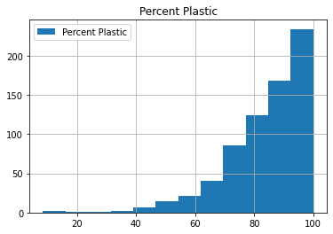

```python
perc_plast_by_beach_type = {}

for i in types:
    perc_plast_by_beach_type[i] = material_percs_df[material_percs_df['BeachType'] == i]

#for i in types:
#    thisdf = perc_plast_by_beach_type[i]
 #   thisdf.hist(column = 'Percent Plastic', bins=12, legend=True)


sandydf = perc_plast_by_beach_type["Sandy"]
sandydf.hist(column = 'Percent Plastic', bins=12, legend=True)
```

#### Sandy ^

```
array([[<AxesSubplot:title={'center':'Percent Plastic'}>]], dtype=object)
```

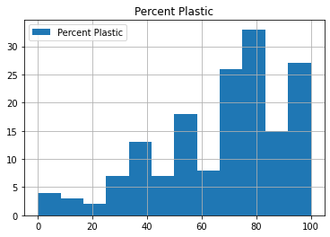

```python
rockydf = perc_plast_by_beach_type["Rocky"]
rockydf.hist(column = 'Percent Plastic', bins=12, legend=True)
```

#### Rocky ^

```
array([[<AxesSubplot:title={'center':'Percent Plastic'}>]], dtype=object)
```

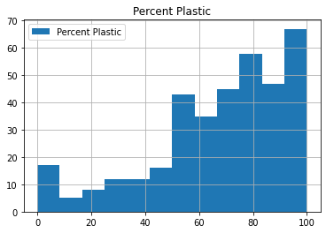

```python
pebbeldf = perc_plast_by_beach_type["Pebbels"]
pebbeldf.hist(column = 'Percent Plastic', bins=12, legend=True)
```

#### Pebbels ^

```
array([[<AxesSubplot:title={'center':'Percent Plastic'}>]], dtype=object)
```

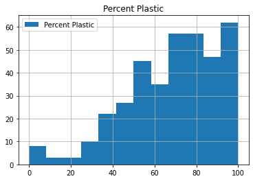

```python
otherdf = perc_plast_by_beach_type["Other (mixed)"]
otherdf.hist(column = 'Percent Plastic', bins=12, legend=True)
```

#### Other (mixed) ^

```python
stats.kruskal(rockydist, otherdist, sandydist, pebbeldist, nan_policy='omit')
```

```
KruskalResult(statistic=13.740136763219578, pvalue=0.003281082744832735)
```

## Below: Stuff that didn't work

```python
#size_df_by_beach_type = size_df.groupby('BeachType').sum().reset_index()

size_df_by_beach_type["% Items > 50 cm"] = 100 * size_df_by_beach_type['Total Big']/(size_df_by_beach_type['Total Big'] + size_df_by_beach_type['Total Small'])

size_df_by_beach_type.head()
ax = size_df_by_beach_type.plot.bar(x='BeachType', y='% Items > 50 cm', rot=0)
```

[output not shown]

```python
rocky_df = material_df_by_beach_type[material_df_by_beach_type['BeachType'] == 'Rocky']
rocky_pie = rocky_df[['Sum of Glass/ceramics', 'Sum of Rubber','Sum of Cloth/textile','Sum of Processed/worked wood','Sum of Plastic','Sum of Paper/Cardboard' ,'Sum of Metal']]

rocky_pie_df = pd.DataFrame({'sums' : rocky_pie},
                            index = SUM_LIST )

#plot = rocky_pie_df.plot.pie(y = 'sums', figsize=(5,5))
```

[output not shown]

```python
# set width of bar
barWidth = 0.25
fig = plt.subplots(figsize =(12, 8))

# set height of bar
IT = [12, 30, 1, 8, 22]
ECE = [28, 6, 16, 5, 10]
CSE = [29, 3, 24, 25, 17]

# Set position of bar on X axis
br1 = np.arange(len(IT))
br2 = [x + barWidth for x in br1]
br3 = [x + barWidth for x in br2]

# Make the plot
plt.bar(br1, IT, color ='r', width = barWidth,
        edgecolor ='grey', label ='IT')
plt.bar(br2, ECE, color ='g', width = barWidth,
        edgecolor ='grey', label ='ECE')
plt.bar(br3, CSE, color ='b', width = barWidth,
        edgecolor ='grey', label ='CSE')

# Adding Xticks
plt.xlabel('Branch', fontweight ='bold', fontsize = 15)
plt.ylabel('Students passed', fontweight ='bold', fontsize = 15)
plt.xticks([r + barWidth for r in range(len(IT))],
        ['2015', '2016', '2017', '2018', '2019'])

plt.legend()
plt.show()
```

[output not shown]

## Sources

[1] https://www.sciencehistory.org/the-history-and-future-of-plastics

[2] https://www.statista.com/statistics/282732/global-production-of-plastics-since-1950/

[3] https://www.condorferries.co.uk/plastic-in-the-ocean-statistics#:~:text=There%20is%20now%205.25%20trillion,their%20way%20into%20our%20oceans.

[4] https://pubs.acs.org/doi/10.1021/es400663f

[5] https://www.blueoceansociety.org/blog/how-does-ocean-plastic-affect-whales/

[6] https://www.maritime-executive.com/editorials/the-fish-we-eat-are-eating-plastic#:~:text=Our%20research%20revealed%20that%20marine,those%20species%20had%20ingested%20plastic.

[7] https://www.biologicaldiversity.org/campaigns/ocean_plastics/#:~:text=Thousands%20of%20seabirds%20and%20sea,get%20caught%20in%20plastic%20litter.

[8] https://www.howitworksdaily.com/why-do-some-beaches-have-sand-and-others-have-pebbles/#:~:text=Higher%2Denergy%20beaches%20are%20often,as%20pebbles%20or%20even%20boulders.&text=The%20chalk%20is%20dissolved%20in,gives%20us%20the%20pebbly%20beaches

[9] https://www.ncbi.nlm.nih.gov/pmc/articles/PMC7269931/#:~:text=The%20COVID%2D19%20pandemic%20and,the%20store%20comes%20to%20home